# Modeling apparent competition

[EFB 370](https://eligurarie.github.io/EFB370/) - Spring 2025

Dr. Gurarie

2026-04-02

Below is a schematic and caption from Boutin et al. 2002 describing the “apparent competition” hypothesis among moose (*Alces alces*) and woodland caribou (*Rangifer tarandus caribou*) in the Oil Sands region of Alberta. In short, intensive sand oil exploration has resulted in rapid and intense fragmentation and logging of the boreal forest, which has improved habitat for moose. Thus, though caribou and moose do not overlap in habitat preferences and do not directly compete, the presence of moose indirectly hurts caribou by increasing the number of wolves. It’s worth reading the caption below carefully.

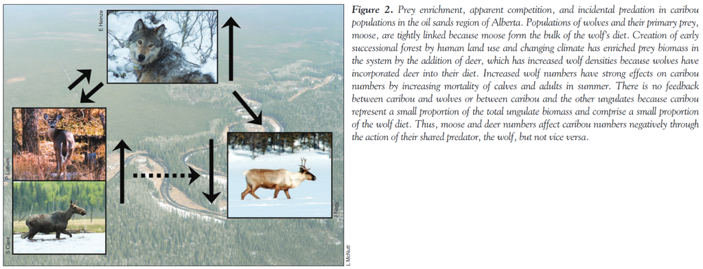

We are going to see if we can capture and quantify that apparent competition dynamic using Lotka-Volterra type predator-prey models with one predator (the wolf) and two prey (the caribou and the moose).

## The model

The model is a **Lotka-Volterra predation model**, but with **two prey species** and some prey carrying capacity. There is no **direct** competion between the prey, as caribou and moose use very different kinds of habitat.

Wolf equation $W(t)$:
$${dW \over dt} = (\gamma_m M + \gamma_c C -
\delta)W$$

Moose equation $M(t)$:
$${dM \over dt} = r_m M \left(1 - {M\over
K_m}\right) - \sigma_m MW$$

Woodland caribou equation $C(t)$:
$${dC \over dt} = r_c C \left(1 - {C\over
K_c} \right)- \sigma_c CW$$

The parameters are defined as follows:

| species | parameter | definition | value pre oil | value post oil |
| --- | --- | --- | --- | --- |
| **caribou** | $r_c$ | intrinsic growth | 0.5 | 0.3 |
|  | $K_c$ | carrying capacity | 1000 | 500 |
|  | $\sigma_c$ | death rate from predation | **TBD** | **TBD** |
| **moose** | $r_m$ | intrinsic growth |  | 0.7 |
|  | $K_m$ | carrying capacity | 10 | 1000 |
|  | $\sigma_m$ | death rate from predation |  | **TBD** |
| **wolf** | $\delta$ | intrinsic death rate | 0.2 | 0.2 |
|  | $\gamma_m$ | conversion rate from moose |  | 0.002 |
|  | $\gamma_c$ | conversion rate from caribou | 0.0005 | 0.0005 |

I’ve programmed this model into an interactive tool at this link: https://egurarie.shinyapps.io/apparentcompetition

## Part I: Pre-Industrialization

> **Easy Exercise 1:** Imagine the first woodland caribou colonized this area when there were no wolves, and no moose. Set up a simulation with an initial caribou population of 1. How many caribou were there after 10 years? How many years - approximtely - does it take to get to carrying capacity (within a rounding error)?

> **Harder Exercise 2:** Let’s say it took 10 years for the first wolves to arrive. After some time, they attained a steady equilibrium of 30 animals in the area, while cutting down the caribou population to 400. So, your starting parameters should now be the number of caribou from the previous exercise and some starting amount of wolves (generally, you would want 2 to have a start for the population…). Simulate this process. In the process, figure out what the value of the predator mortality parameter ($\sigma_c$) must be to obtain these steady states.

> *Note, you could, in theory, solve for this without guess-and-checking by finding where the (vertical) predator isocline intercepts with the (slanty) prey isocoline, but then you’d be doing algebra.*

## Part II: Post-Industrialization

All that business happened at some point after the last ice age, and the boreal caribou and wolves have been happily living their lives at their - relatively - low numbers since then. But then people discovered that there was lots and lots of thick oil in the sandstone under the boreal forest, which they immediately began to slice and dice. One of the consequences of these actions was transforming an intact mosaic of old-growth boreal forest and bogs into a patchwork of clearcuts and early successional browse which are mannah for moose.

> **Exercise 3:** Moose pack a much more powerful protein punch for wolves (4 x the mass = 4 x the conversion factor). They are also somewhat more reproductively productive in this improved (for them) habitat, so their intrinsic growth $r_m$ is higher (see table). Introduce some moose into this system. What is the effect on the caribou and wolf populations?

## Part III: Mitigation strategies

In Canada, there are active mitigation measures to help the (highly endangered) woodland caribou (none of which involve improving the habitat or slowing down development). Instead, they involve either culling moose or culling wolves.

> **Exercise 4a:** How much do you need to increase the death rate of wolves to get the caribou to a target population of 140 animals?

> **Exercise 4b:** How much do you need to decrease the reproductive rate of moose to get the caribou to a target population of 140 animals?